# TreeSearch vs TNT: Benchmark Comparison

Author

TreeSearch Development

Published

March 21, 2026

## Overview

This report compares **TreeSearch** (C++ driven search) against **TNT 1.6** (Goloboff & Catalano 2016) on identical phylogenetic search problems.

Both programs implement “new technology” heuristic searches: random addition sequences, TBR branch swapping, sectorial searches, ratchet perturbation, drift, and tree fusing. We compare search quality (best score found) and wall-clock speed across a range of morphological datasets.

### Ensuring a fair comparison

The `inapplicable.phyData` datasets bundled with TreeSearch contain inapplicable (`-`) tokens. TreeSearch and TNT handle these differently: TreeSearch uses the Brazeau et al. (2019) three-pass algorithm, while TNT treats inapplicable as a regular character state. To ensure both programs optimise the **same** objective function — standard Fitch parsimony — we replace all inapplicable tokens with missing data (`?`) before analysis.

```r
# Replace inapplicable tokens with missing data
clean_inapplicable <- function(phyDat_obj) {
  mat <- PhyDatToMatrix(phyDat_obj)
  mat[mat == "-"] <- "?"
  MatrixToPhyDat(mat)
}

# Prepare dataset for TreeSearch C++ bridge
prepare_ts_data <- function(dataset) {
  at <- attributes(dataset)
  list(
    contrast = at$contrast,
    tip_data = matrix(unlist(dataset, use.names = FALSE),
                      nrow = length(dataset), byrow = TRUE),
    weight = at$weight,
    levels = at$levels,
    n_taxa = length(dataset),
    n_chars = sum(at$weight)
  )
}

# Run TNT search; returns list(score, n_trees, wall_s)
run_tnt <- function(data_file, timeout_s = 30, seed = 1,
                    hits = 5, reps = 20, weighting = "EW",
                    concavity = 3) {
  commands <- c(
    "mxram 1024;",
    sprintf("proc %s;", data_file),
    sprintf("rseed %d;", seed)
  )
  if (weighting == "IW") {
    commands <- c(commands, sprintf("piwe=%d;", concavity))
  }
  hh <- timeout_s %/% 3600
  mm <- (timeout_s %% 3600) %/% 60
  ss <- timeout_s %% 60
  commands <- c(commands,
    sprintf("timeout %d:%02d:%02d;", hh, mm, ss),
    sprintf("xmult=hits %d replic %d;", hits, reps),
    "best;", "quit;"
  )

  script_path <- file.path(STAGING_DIR, "tntbench.run")
  writeLines(commands, script_path)

  old_wd <- setwd(STAGING_DIR)
  on.exit(setwd(old_wd), add = TRUE)

  t0 <- proc.time()
  output <- withCallingHandlers(
    system2(TNT_EXE, args = "tntbench.run;",
            stdout = TRUE, stderr = TRUE, timeout = timeout_s + 30),
    warning = function(w) invokeRestart("muffleWarning")
  )
  wall_s <- as.double((proc.time() - t0)[3])

  output <- iconv(output, from = "", to = "UTF-8", sub = "")
  out_text <- paste(output, collapse = "\n")

  score <- NA_real_
  m <- regmatches(out_text, regexpr("Best score:\\s+([0-9.]+)", out_text))
  if (length(m) == 1) score <- as.numeric(sub("Best score:\\s+", "", m))

  n_trees <- NA_integer_
  m <- regmatches(out_text, regexpr("([0-9]+) trees? retained", out_text))
  if (length(m) == 1) n_trees <- as.integer(sub(" trees? retained", "", m))

  list(score = score, n_trees = n_trees, wall_s = wall_s)
}

# Run TreeSearch driven search; returns list(score, n_trees, wall_s)
run_treesearch <- function(ds, timeout_s = 30, seed = 1,
                           hits = 5, reps = 20) {
  set.seed(seed)
  t0 <- proc.time()
  result <- TreeSearch:::ts_driven_search(
    ds$contrast, ds$tip_data, ds$weight, ds$levels,
    maxReplicates = as.integer(reps),
    targetHits = as.integer(hits),
    maxSeconds = as.double(timeout_s),
    verbosity = 0L, nThreads = 1L
  )
  wall_s <- as.double((proc.time() - t0)[3])

  list(score = result$best_score, n_trees = result$pool_size,
       wall_s = wall_s, replicates = result$replicates,
       hits = result$hits_to_best)
}
```

## Datasets

We use 14 morphological datasets from `inapplicable.phyData`, spanning 20–88 taxa. All inapplicable tokens are replaced with missing data.

```r
BENCHMARK_NAMES <- c(
  "Longrich2010", "Vinther2008", "Sansom2010", "DeAssis2011",
  "Aria2015", "Wortley2006", "Griswold1999", "Schulze2007",
  "Eklund2004", "Agnarsson2004", "Zanol2014", "Zhu2013",
  "Giles2015", "Dikow2009"
)

datasets <- list()
for (nm in BENCHMARK_NAMES) {
  raw <- inapplicable.phyData[[nm]]
  clean <- clean_inapplicable(raw)
  datasets[[nm]] <- prepare_ts_data(clean)

  # Export to TNT format
  WriteTntCharacters(clean,
                     filepath = file.path(STAGING_DIR, paste0(nm, ".tnt")))
}

dataset_info <- map_dfr(names(datasets), \(nm) {
  ds <- datasets[[nm]]
  tibble(dataset = nm, n_taxa = ds$n_taxa, n_chars = ds$n_chars)
})

kable(dataset_info, caption = "Benchmark datasets (inapplicable → missing)")
```

Benchmark datasets (inapplicable → missing)

| dataset | n_taxa | n_chars |
| --- | --- | --- |
| Longrich2010 | 20 | 93 |
| Vinther2008 | 23 | 57 |
| Sansom2010 | 23 | 109 |
| DeAssis2011 | 33 | 50 |
| Aria2015 | 35 | 50 |
| Wortley2006 | 37 | 105 |
| Griswold1999 | 43 | 137 |
| Schulze2007 | 52 | 58 |
| Eklund2004 | 54 | 131 |
| Agnarsson2004 | 62 | 242 |
| Zanol2014 | 74 | 213 |
| Zhu2013 | 75 | 253 |
| Giles2015 | 78 | 236 |
| Dikow2009 | 88 | 220 |

## Run comparison

Each dataset is searched with equal-weights Fitch parsimony. Both engines are given the same timeout, convergence criterion, and random seed. TreeSearch uses `nThreads = 1` for a single-threaded comparison.

```r
TIMEOUT <- 10   # seconds per search
SEEDS <- 1:3
HITS <- 5L
REPS <- 20L

rows <- list()
idx <- 0L
n_total <- length(BENCHMARK_NAMES) * length(SEEDS)

for (nm in BENCHMARK_NAMES) {
  ds <- datasets[[nm]]
  data_file <- paste0(nm, ".tnt")

  for (seed in SEEDS) {
    idx <- idx + 1L

    tnt <- run_tnt(data_file, timeout_s = TIMEOUT, seed = seed,
                   hits = HITS, reps = REPS)
    ts <- run_treesearch(ds, timeout_s = TIMEOUT, seed = seed,
                         hits = HITS, reps = REPS)

    rows[[idx]] <- tibble(
      dataset = nm, n_taxa = ds$n_taxa, n_chars = ds$n_chars,
      seed = seed, timeout_s = TIMEOUT,
      tnt_score = tnt$score, tnt_trees = tnt$n_trees,
      tnt_wall_s = round(tnt$wall_s, 3),
      ts_score = ts$score, ts_trees = ts$n_trees,
      ts_wall_s = round(ts$wall_s, 3),
      ts_reps = ts$replicates, ts_hits = ts$hits
    )
  }
}

results <- bind_rows(rows)
```

## Score comparison

With inapplicable tokens replaced by missing data, both engines optimise the same Fitch objective. Any score difference reflects search effectiveness, not algorithmic differences.

```r
score_summary <- results |>
  group_by(dataset, n_taxa, n_chars) |>
  summarise(
    tnt_best = min(tnt_score), ts_best = min(ts_score),
    tnt_median = median(tnt_score), ts_median = median(ts_score),
    agree = min(tnt_score) == min(ts_score),
    .groups = "drop"
  ) |>
  arrange(n_taxa) |>
  mutate(delta = ts_best - tnt_best)

kable(score_summary, digits = 1)
```

Table 1: Best and median scores per dataset (across 3 seeds)

| dataset | n_taxa | n_chars | tnt_best | ts_best | tnt_median | ts_median | agree | delta |
| --- | --- | --- | --- | --- | --- | --- | --- | --- |
| Longrich2010 | 20 | 93 | 131 | 131 | 131 | 131 | TRUE | 0 |
| Sansom2010 | 23 | 109 | 188 | 188 | 188 | 188 | TRUE | 0 |
| Vinther2008 | 23 | 57 | 78 | 78 | 78 | 78 | TRUE | 0 |
| DeAssis2011 | 33 | 50 | 64 | 64 | 64 | 64 | TRUE | 0 |
| Aria2015 | 35 | 50 | 142 | 142 | 142 | 142 | TRUE | 0 |
| Wortley2006 | 37 | 105 | 479 | 493 | 479 | 493 | FALSE | 14 |
| Griswold1999 | 43 | 137 | 394 | 394 | 394 | 394 | TRUE | 0 |
| Schulze2007 | 52 | 58 | 155 | 155 | 155 | 155 | TRUE | 0 |
| Eklund2004 | 54 | 131 | 440 | 444 | 440 | 444 | FALSE | 4 |
| Agnarsson2004 | 62 | 242 | 765 | 765 | 765 | 765 | TRUE | 0 |
| Zanol2014 | 74 | 213 | 1261 | 1268 | 1261 | 1274 | FALSE | 7 |
| Zhu2013 | 75 | 253 | 624 | 635 | 624 | 636 | FALSE | 11 |
| Giles2015 | 78 | 236 | 670 | 674 | 670 | 679 | FALSE | 4 |
| Dikow2009 | 88 | 220 | 1606 | 1607 | 1606 | 1607 | FALSE | 1 |

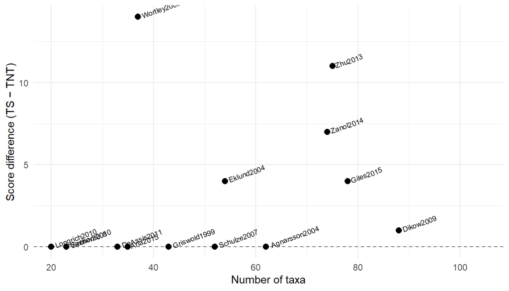

Figure 1: Score difference (TreeSearch best − TNT best) vs dataset size. Zero means both engines found the same optimum.

```r
ggplot(score_summary, aes(n_taxa, delta)) +
  geom_hline(yintercept = 0, linetype = "dashed", alpha = 0.5) +
  geom_point(size = 2.5) +
  geom_text(aes(label = dataset), hjust = -0.1, size = 2.5, angle = 20) +
  labs(x = "Number of taxa", y = "Score difference (TS − TNT)") +
  theme_minimal() +
  scale_x_continuous(expand = expansion(mult = c(0.05, 0.3)))
```

## Timing comparison

```r
timing <- results |>
  group_by(dataset, n_taxa) |>
  summarise(
    tnt_median_s = round(median(tnt_wall_s), 2),
    ts_median_s = round(median(ts_wall_s), 2),
    .groups = "drop"
  ) |>
  mutate(ratio_ts_tnt = round(ts_median_s / tnt_median_s, 1)) |>
  arrange(n_taxa)

kable(timing)
```

Table 2: Median wall-clock time (seconds) and speed ratio

| dataset | n_taxa | tnt_median_s | ts_median_s | ratio_ts_tnt |
| --- | --- | --- | --- | --- |
| Longrich2010 | 20 | 0.62 | 0.74 | 1.2 |
| Sansom2010 | 23 | 0.64 | 3.09 | 4.8 |
| Vinther2008 | 23 | 0.41 | 0.57 | 1.4 |
| DeAssis2011 | 33 | 0.25 | 0.50 | 2.0 |
| Aria2015 | 35 | 0.72 | 1.33 | 1.8 |
| Wortley2006 | 37 | 1.85 | 3.20 | 1.7 |
| Griswold1999 | 43 | 1.18 | 2.99 | 2.5 |
| Schulze2007 | 52 | 0.98 | 2.18 | 2.2 |
| Eklund2004 | 54 | 1.73 | 10.05 | 5.8 |
| Agnarsson2004 | 62 | 1.60 | 2.26 | 1.4 |
| Zanol2014 | 74 | 10.25 | 10.05 | 1.0 |
| Zhu2013 | 75 | 6.55 | 10.06 | 1.5 |
| Giles2015 | 78 | 6.08 | 10.05 | 1.7 |
| Dikow2009 | 88 | 8.61 | 10.11 | 1.2 |

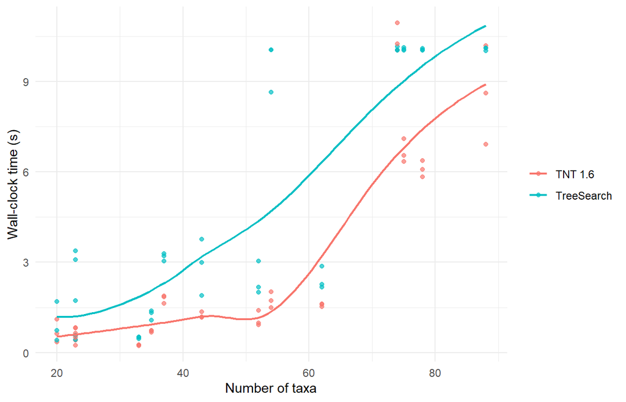

Figure 2: Wall-clock time vs number of taxa

```r
results_long <- results |>
  select(dataset, n_taxa, seed, tnt_wall_s, ts_wall_s) |>
  pivot_longer(c(tnt_wall_s, ts_wall_s),
               names_to = "engine", values_to = "wall_s") |>
  mutate(engine = if_else(engine == "tnt_wall_s", "TNT 1.6", "TreeSearch"))

ggplot(results_long, aes(n_taxa, wall_s, colour = engine)) +
  geom_point(alpha = 0.7) +
  geom_smooth(method = "loess", se = FALSE, linewidth = 0.8) +
  labs(x = "Number of taxa", y = "Wall-clock time (s)", colour = NULL) +
  theme_minimal()
```

## Score quality

How often does each engine find the overall best-known score (the minimum across both engines and all seeds)?

```r
quality <- results |>
  group_by(dataset, n_taxa) |>
  mutate(
    best = min(c(tnt_score, ts_score)),
    tnt_hit = tnt_score <= best,
    ts_hit = ts_score <= best
  ) |>
  summarise(
    n = n(),
    tnt_pct = round(100 * mean(tnt_hit), 0),
    ts_pct = round(100 * mean(ts_hit), 0),
    .groups = "drop"
  ) |>
  arrange(n_taxa)

kable(quality)
```

Table 3: Percentage of runs finding the best-known score

| dataset | n_taxa | n | tnt_pct | ts_pct |
| --- | --- | --- | --- | --- |
| Longrich2010 | 20 | 3 | 100 | 100 |
| Sansom2010 | 23 | 3 | 100 | 67 |
| Vinther2008 | 23 | 3 | 100 | 100 |
| DeAssis2011 | 33 | 3 | 100 | 100 |
| Aria2015 | 35 | 3 | 100 | 100 |
| Wortley2006 | 37 | 3 | 100 | 0 |
| Griswold1999 | 43 | 3 | 100 | 100 |
| Schulze2007 | 52 | 3 | 100 | 100 |
| Eklund2004 | 54 | 3 | 100 | 0 |
| Agnarsson2004 | 62 | 3 | 100 | 100 |
| Zanol2014 | 74 | 3 | 100 | 0 |
| Zhu2013 | 75 | 3 | 100 | 0 |
| Giles2015 | 78 | 3 | 100 | 0 |
| Dikow2009 | 88 | 3 | 100 | 0 |

## Full results

```r
kable(results |> arrange(n_taxa, dataset, seed), digits = 2)
```

Table 4: All individual runs

| dataset | n_taxa | n_chars | seed | timeout_s | tnt_score | tnt_trees | tnt_wall_s | ts_score | ts_trees | ts_wall_s | ts_reps | ts_hits |
| --- | --- | --- | --- | --- | --- | --- | --- | --- | --- | --- | --- | --- |
| Longrich2010 | 20 | 93 | 1 | 10 | 131 | 6 | 1.10 | 131 | 100 | 1.69 | 7 | 5 |
| Longrich2010 | 20 | 93 | 2 | 10 | 131 | 6 | 0.62 | 131 | 100 | 0.74 | 7 | 5 |
| Longrich2010 | 20 | 93 | 3 | 10 | 131 | 6 | 0.35 | 131 | 100 | 0.41 | 7 | 5 |
| Sansom2010 | 23 | 109 | 1 | 10 | 188 | 2 | 0.64 | 188 | 2 | 3.38 | 20 | 3 |
| Sansom2010 | 23 | 109 | 2 | 10 | 188 | 2 | 0.50 | 188 | 2 | 1.72 | 20 | 4 |
| Sansom2010 | 23 | 109 | 3 | 10 | 188 | 2 | 0.83 | 189 | 6 | 3.09 | 20 | 4 |
| Vinther2008 | 23 | 57 | 1 | 10 | 78 | 20 | 0.41 | 78 | 33 | 0.43 | 6 | 5 |
| Vinther2008 | 23 | 57 | 2 | 10 | 78 | 20 | 0.82 | 78 | 31 | 0.58 | 5 | 5 |
| Vinther2008 | 23 | 57 | 3 | 10 | 78 | 13 | 0.24 | 78 | 32 | 0.57 | 9 | 5 |
| DeAssis2011 | 33 | 50 | 1 | 10 | 64 | 11 | 0.25 | 64 | 100 | 0.45 | 5 | 5 |
| DeAssis2011 | 33 | 50 | 2 | 10 | 64 | 10 | 0.23 | 64 | 100 | 0.52 | 5 | 5 |
| DeAssis2011 | 33 | 50 | 3 | 10 | 64 | 11 | 0.25 | 64 | 100 | 0.50 | 5 | 5 |
| Aria2015 | 35 | 50 | 1 | 10 | 142 | 64 | 0.74 | 142 | 100 | 1.39 | 19 | 5 |
| Aria2015 | 35 | 50 | 2 | 10 | 142 | 55 | 0.68 | 142 | 100 | 1.33 | 17 | 5 |
| Aria2015 | 35 | 50 | 3 | 10 | 142 | 56 | 0.72 | 142 | 100 | 1.07 | 12 | 5 |
| Wortley2006 | 37 | 105 | 1 | 10 | 479 | 13 | 1.85 | 494 | 4 | 3.29 | 20 | 3 |
| Wortley2006 | 37 | 105 | 2 | 10 | 479 | 15 | 1.88 | 493 | 2 | 3.20 | 20 | 0 |
| Wortley2006 | 37 | 105 | 3 | 10 | 479 | 12 | 1.63 | 493 | 8 | 3.04 | 20 | 3 |
| Griswold1999 | 43 | 137 | 1 | 10 | 394 | 11 | 1.17 | 394 | 15 | 2.99 | 13 | 5 |
| Griswold1999 | 43 | 137 | 2 | 10 | 394 | 14 | 1.36 | 394 | 11 | 1.89 | 8 | 5 |
| Griswold1999 | 43 | 137 | 3 | 10 | 394 | 15 | 1.18 | 394 | 17 | 3.77 | 17 | 5 |
| Schulze2007 | 52 | 58 | 1 | 10 | 155 | 80 | 0.92 | 155 | 100 | 2.18 | 14 | 5 |
| Schulze2007 | 52 | 58 | 2 | 10 | 155 | 76 | 1.40 | 155 | 100 | 2.01 | 12 | 5 |
| Schulze2007 | 52 | 58 | 3 | 10 | 155 | 77 | 0.98 | 155 | 100 | 3.03 | 20 | 5 |
| Eklund2004 | 54 | 131 | 1 | 10 | 440 | 76 | 1.50 | 444 | 100 | 8.64 | 20 | 2 |
| Eklund2004 | 54 | 131 | 2 | 10 | 440 | 80 | 2.02 | 444 | 37 | 10.05 | 20 | 1 |
| Eklund2004 | 54 | 131 | 3 | 10 | 440 | 76 | 1.73 | 444 | 36 | 10.05 | 20 | 1 |
| Agnarsson2004 | 62 | 242 | 1 | 10 | 765 | 1 | 1.60 | 765 | 1 | 2.26 | 5 | 5 |
| Agnarsson2004 | 62 | 242 | 2 | 10 | 765 | 1 | 1.53 | 765 | 1 | 2.86 | 5 | 5 |
| Agnarsson2004 | 62 | 242 | 3 | 10 | 765 | 1 | 1.62 | 765 | 1 | 2.18 | 5 | 5 |
| Zanol2014 | 74 | 213 | 1 | 10 | 1261 | 13 | 10.04 | 1274 | 1 | 10.16 | 7 | 1 |
| Zanol2014 | 74 | 213 | 2 | 10 | 1261 | 17 | 10.25 | 1268 | 1 | 10.05 | 6 | 1 |
| Zanol2014 | 74 | 213 | 3 | 10 | 1261 | 14 | 10.95 | 1274 | 1 | 10.03 | 5 | 0 |
| Zhu2013 | 75 | 253 | 1 | 10 | 624 | 27 | 7.10 | 648 | 1 | 10.06 | 10 | 1 |
| Zhu2013 | 75 | 253 | 2 | 10 | 624 | 26 | 6.55 | 635 | 1 | 10.13 | 10 | 1 |
| Zhu2013 | 75 | 253 | 3 | 10 | 624 | 32 | 6.34 | 636 | 1 | 10.04 | 12 | 1 |
| Giles2015 | 78 | 236 | 1 | 10 | 670 | 40 | 6.08 | 674 | 1 | 10.09 | 10 | 0 |
| Giles2015 | 78 | 236 | 2 | 10 | 670 | 39 | 6.37 | 679 | 1 | 10.05 | 10 | 1 |
| Giles2015 | 78 | 236 | 3 | 10 | 670 | 35 | 5.83 | 683 | 1 | 10.03 | 11 | 1 |
| Dikow2009 | 88 | 220 | 1 | 10 | 1606 | 8 | 8.61 | 1608 | 2 | 10.02 | 9 | 2 |
| Dikow2009 | 88 | 220 | 2 | 10 | 1606 | 10 | 10.19 | 1607 | 3 | 10.12 | 9 | 3 |
| Dikow2009 | 88 | 220 | 3 | 10 | 1606 | 11 | 6.91 | 1607 | 2 | 10.11 | 8 | 2 |